# Natural_Language_Processing_(NLP)_Amazon_GH1043409

## GISMA University of Applied Sciences

## M508B Big Data Analytics (SS0325)

## GH1043409

## Natural Language Processing (NLP) Analysis using Text Classification for Consumer Reviews of Amazon Products

## 1. Problem Statement

As a data scientist at Amazon, the company focuses on building AI solutions for better customer support and increase on sales, I was given the task to designing a Natural Language Processing (NLP) solution to assist in solving business problem.

### Business Context

Similar to other e-commerce platforms, our company processes a large number of customer comments on product pages. Although these reviews offer valuable information, they mostly come in an unstructured text format. Getting value from this data by hand is time consuming and defficult to get the actual picture.

Customer reviews are important for product success on Amazon. They have an impact on buying choices, show how happy people are, point out problems, and show trends across different categories.

### Business Problem

The main issue is that we can't automatically extract insights from customer reviews. If we don't have a reliable way to judge reviews and get meaning from user comments, the company could face issues, like:

- Slow discovery of flawed or weak products.
- Lost chances to push well-performing products.
- Not being able to follow changing customer tastes on a large scale.

So, the goal is to create a system that uses language processing to automatically sort the reviews of Amazon product, marking them as Positive, Negative, or Neutral. This will help our internal analytics, help customer service know what to focus on, and aid product teams.

### Why NLP and How It Helps

To solve this problem, we can use Natural Language Processing methods, mainly text classification. By training a model with customer reviews, we can learn patterns that show different sentiments.

Fixing this problem will let us:

- Quickly find and deal with bad reviews.
- Watch how happy customers are with different products.
- Make automatic summaries of customer feedback for product managers.
- Build better content moderation and flagging systems.

### Data Collection Strategy

For this project I will be using Amazon customer review data from Kaggle.

I'll use the ReviewText for my NLP model.

You can find the data here: https://www.kaggle.com/datasets/datafiniti/consumer-reviews-of-amazon-products/data

### Problem Formulation as an NLP Task

In natural language processing, I've setup this problem as a text classification task.

- **Input**: A customer review. For example, “The product stopped working after one week.”
- **Output**: A specific sentiment class: Negative, Neutral, or Positive.

Importing Libraries

```python
import re
import string
import unicodedata
import itertools

import pandas as pd
import numpy as np
from sklearn.feature_extraction.text import TfidfVectorizer
from sklearn.feature_extraction.text import CountVectorizer
from sklearn.model_selection import train_test_split
from sklearn.linear_model import LogisticRegression
from sklearn.ensemble import RandomForestClassifier
from sklearn.metrics import accuracy_score, confusion_matrix, classification_report
from sklearn.naive_bayes import GaussianNB
from collections import Counter

import seaborn as sns
import matplotlib.pyplot as plt
import plotly.express as px

import os
import nltk
from nltk.tokenize import word_tokenize
from nltk.corpus import stopwords
from nltk.stem import PorterStemmer

!pip install vaderSentiment

from vaderSentiment.vaderSentiment import SentimentIntensityAnalyzer

# Download NLTK resources (only needs to be run once)
nltk.download('punkt')
nltk.download('stopwords')
```

## 2. Loading Data.

1. Click the link to the data
2. Download the dataset from kaggle.
3. Upload the data on Google colab
4. Assign the data set to the variable (1429_1.csv)
5. Viewing first 5 data

```python
df = pd.read_csv(
    "/content/1429_1.csv",
    dtype={1: str, 10: str},
    low_memory=False
)

df.head()
```

|  | id | name | asins | brand | categories | keys | manufacturer | reviews.date | reviews.dateAdded | reviews.dateSeen | ... | reviews.doRecommend | reviews.id | reviews.numHelpful | reviews.rating | reviews.sourceURLs | reviews.text | reviews.title | reviews.userCity | reviews.userProvince | reviews.username |
| --- | --- | --- | --- | --- | --- | --- | --- | --- | --- | --- | --- | --- | --- | --- | --- | --- | --- | --- | --- | --- | --- |
| 0 | AVqkIhwDv8e3D1O-lebb | All-New Fire HD 8 Tablet, 8 HD Display, Wi-Fi,... | B01AHB9CN2 | Amazon | Electronics,iPad & Tablets,All Tablets,Fire Ta... | 841667104676,amazon/53004484,amazon/b01ahb9cn2... | Amazon | 2017-01-13T00:00:00.000Z | 2017-07-03T23:33:15Z | 2017-06-07T09:04:00.000Z,2017-04-30T00:45:00.000Z | ... | True | NaN | 0.0 | 5.0 | http://reviews.bestbuy.com/3545/5620406/review... | This product so far has not disappointed. My c... | Kindle | NaN | NaN | Adapter |
| 1 | AVqkIhwDv8e3D1O-lebb | All-New Fire HD 8 Tablet, 8 HD Display, Wi-Fi,... | B01AHB9CN2 | Amazon | Electronics,iPad & Tablets,All Tablets,Fire Ta... | 841667104676,amazon/53004484,amazon/b01ahb9cn2... | Amazon | 2017-01-13T00:00:00.000Z | 2017-07-03T23:33:15Z | 2017-06-07T09:04:00.000Z,2017-04-30T00:45:00.000Z | ... | True | NaN | 0.0 | 5.0 | http://reviews.bestbuy.com/3545/5620406/review... | great for beginner or experienced person. Boug... | very fast | NaN | NaN | truman |
| 2 | AVqkIhwDv8e3D1O-lebb | All-New Fire HD 8 Tablet, 8 HD Display, Wi-Fi,... | B01AHB9CN2 | Amazon | Electronics,iPad & Tablets,All Tablets,Fire Ta... | 841667104676,amazon/53004484,amazon/b01ahb9cn2... | Amazon | 2017-01-13T00:00:00.000Z | 2017-07-03T23:33:15Z | 2017-06-07T09:04:00.000Z,2017-04-30T00:45:00.000Z | ... | True | NaN | 0.0 | 5.0 | http://reviews.bestbuy.com/3545/5620406/review... | Inexpensive tablet for him to use and learn on... | Beginner tablet for our 9 year old son. | NaN | NaN | DaveZ |
| 3 | AVqkIhwDv8e3D1O-lebb | All-New Fire HD 8 Tablet, 8 HD Display, Wi-Fi,... | B01AHB9CN2 | Amazon | Electronics,iPad & Tablets,All Tablets,Fire Ta... | 841667104676,amazon/53004484,amazon/b01ahb9cn2... | Amazon | 2017-01-13T00:00:00.000Z | 2017-07-03T23:33:15Z | 2017-06-07T09:04:00.000Z,2017-04-30T00:45:00.000Z | ... | True | NaN | 0.0 | 4.0 | http://reviews.bestbuy.com/3545/5620406/review... | I've had my Fire HD 8 two weeks now and I love... | Good!!! | NaN | NaN | Shacks |
| 4 | AVqkIhwDv8e3D1O-lebb | All-New Fire HD 8 Tablet, 8 HD Display, Wi-Fi,... | B01AHB9CN2 | Amazon | Electronics,iPad & Tablets,All Tablets,Fire Ta... | 841667104676,amazon/53004484,amazon/b01ahb9cn2... | Amazon | 2017-01-12T00:00:00.000Z | 2017-07-03T23:33:15Z | 2017-06-07T09:04:00.000Z,2017-04-30T00:45:00.000Z | ... | True | NaN | 0.0 | 5.0 | http://reviews.bestbuy.com/3545/5620406/review... | I bought this for my grand daughter when she c... | Fantastic Tablet for kids | NaN | NaN | explore42 |

5 rows × 21 columns

```python
df.info()
```

```
<class 'pandas.core.frame.DataFrame'>
RangeIndex: 34660 entries, 0 to 34659
Data columns (total 21 columns):
 #   Column                Non-Null Count  Dtype
---  ------                --------------  -----
 0   id                    34660 non-null  object
 1   name                  27900 non-null  object
 2   asins                 34658 non-null  object
 3   brand                 34660 non-null  object
 4   categories            34660 non-null  object
 5   keys                  34660 non-null  object
 6   manufacturer          34660 non-null  object
 7   reviews.date          34621 non-null  object
 8   reviews.dateAdded     24039 non-null  object
 9   reviews.dateSeen      34660 non-null  object
 10  reviews.didPurchase   1 non-null      object
 11  reviews.doRecommend   34066 non-null  object
 12  reviews.id            1 non-null      float64
 13  reviews.numHelpful    34131 non-null  float64
 14  reviews.rating        34627 non-null  float64
 15  reviews.sourceURLs    34660 non-null  object
 16  reviews.text          34659 non-null  object
 17  reviews.title         34654 non-null  object
 18  reviews.userCity      0 non-null      float64
 19  reviews.userProvince  0 non-null      float64
 20  reviews.username      34653 non-null  object
dtypes: float64(5), object(16)
memory usage: 5.6+ MB
```

```python
df.shape
```

```
(34660, 21)
```

### 3. Data Cleaning

Does the dataset suffer from any data quality issues? Yes, the data has some null columns.

```python
print("Checking for missing values in each column:")
print(df.isnull().sum())
```

```
Checking for missing values in each column:
id                          0
name                     6760
asins                       2
brand                       0
categories                  0
keys                        0
manufacturer                0
reviews.date               39
reviews.dateAdded       10621
reviews.dateSeen            0
reviews.didPurchase     34659
reviews.doRecommend       594
reviews.id              34659
reviews.numHelpful        529
reviews.rating             33
reviews.sourceURLs          0
reviews.text                1
reviews.title               6
reviews.userCity        34660
reviews.userProvince    34660
reviews.username            7
dtype: int64
```

Missing values in text fields can cause problems later in NLP pipelines (e.g., during tokenization or vectorization).

By filling missing entries with a placeholder ('-'), you prevent errors and make it easier to identify "empty" content.

This ensures that the model or preprocessing steps do not break when encountering missing fields.

```python
# Clean column (fixes hidden whitespace issues!)
cols_to_fill = ['reviews.username', 'reviews.title', 'reviews.text']
df[cols_to_fill] = df[cols_to_fill].fillna('-')
```

```python
print(df.isnull().sum())
```

```
id                          0
name                     6760
asins                       2
brand                       0
categories                  0
keys                        0
manufacturer                0
reviews.date               39
reviews.dateAdded       10621
reviews.dateSeen            0
reviews.didPurchase     34659
reviews.doRecommend       594
reviews.id              34659
reviews.numHelpful        529
reviews.rating             33
reviews.sourceURLs          0
reviews.text                0
reviews.title               0
reviews.userCity        34660
reviews.userProvince    34660
reviews.username            0
dtype: int64
```

Text Preprocessing

```python
print("Exact column names:")
for col in df.columns:
    print(f"- {col}")
```

```
Exact column names:
- id
- name
- asins
- brand
- categories
- keys
- manufacturer
- reviews.date
- reviews.dateAdded
- reviews.dateSeen
- reviews.didPurchase
- reviews.doRecommend
- reviews.id
- reviews.numHelpful
- reviews.rating
- reviews.sourceURLs
- reviews.text
- reviews.title
- reviews.userCity
- reviews.userProvince
- reviews.username
```

### Cleaning Steps

The raw dataset contained ReviewText along with a numerical Rating. Before performing any NLP transformations, I applied the following steps to clean the text data:

Lowercasing: All text was converted to lowercase to ensure uniformity and reduce sparsity caused by case distinctions (e.g., "Good" vs. "good").

Punctuation Removal: Special characters, punctuation marks, and non-alphanumeric symbols were removed using regular expressions. This step helps prevent the model from learning noise.

Stop Word Removal: Common English stopwords (e.g., "is", "the", "and") were removed using NLTK's stopwords list. These words typically do not contribute significantly to the sentiment and can dilute the signal.

Tokenization: The text was split into individual tokens (words), allowing for better preprocessing and later stages like lemmatization or vectorization.

```python
stemmer = PorterStemmer()
stop_words = set(stopwords.words('english'))

def clean_text(text):
    if isinstance(text, str):
        text = text.lower()
        text = re.sub(r'http\S+|www\S+|https\S+', '', text)
        text = re.sub(r'\[.*?\]\(.*?\)', '', text)
        text = re.sub(r'@\w+', '', text)
        text = text.translate(str.maketrans('', '', string.punctuation))
    return text

def tokenize_text(text):
    return re.findall(r'\b\w+\b', text) if isinstance(text, str) else text

def remove_stopwords(tokens):
    return [word for word in tokens if word not in stop_words] if isinstance(tokens, list) else tokens

def stem_tokens(tokens):
    return [stemmer.stem(token) for token in tokens] if isinstance(tokens, list) else tokens

# === Apply preprocessing pipeline ===
df['Cleaned_Review'] = df['reviews.text'].apply(clean_text)
df['Tokenized_Review'] = df['Cleaned_Review'].apply(tokenize_text)
df['No_Stopwords_Review'] = df['Tokenized_Review'].apply(remove_stopwords)
df['Stemmed_Review'] = df['No_Stopwords_Review'].apply(stem_tokens)

print(df[['reviews.text', 'Cleaned_Review', 'Tokenized_Review', 'No_Stopwords_Review', 'Stemmed_Review']].head())
```

```
                                        reviews.text  \
0  This product so far has not disappointed. My c...
1  great for beginner or experienced person. Boug...
2  Inexpensive tablet for him to use and learn on...
3  I've had my Fire HD 8 two weeks now and I love...
4  I bought this for my grand daughter when she c...

                                      Cleaned_Review  \
0  this product so far has not disappointed my ch...
1  great for beginner or experienced person bough...
2  inexpensive tablet for him to use and learn on...
3  ive had my fire hd 8 two weeks now and i love ...
4  i bought this for my grand daughter when she c...

                                    Tokenized_Review  \
```

[output cut: 19 more lines]

## 4. Sentiment Analysis

Methodology My approach involved the following steps:

compound: a normalized overall sentiment score between -1 (most negative) and +1 (most positive),

pos, neu, and neg: the proportion of text that is positive, neutral, or negative respectively.

Safe Text Handling: To ensure robustness, I wrapped the sentiment analysis function with a check to handle missing or empty strings. Empty reviews were assigned a default neutral sentiment score.

Sentiment Classification: I derived discrete sentiment labels (Positive, Neutral, Negative) from the compound score using commonly accepted VADER thresholds:

compound ≥ 0.05 → Positive

compound ≤ -0.05 → Negative

Otherwise → Neutral

```python
analyzer = SentimentIntensityAnalyzer()

def get_sentiment(review):
    if isinstance(review, str) and review.strip():
        return analyzer.polarity_scores(review)
    else:
        return {'compound': 0.0, 'pos': 0.0, 'neu': 1.0, 'neg': 0.0}

def classify_sentiment(compound_score):
    if compound_score >= 0.05:
        return 'Positive'
    elif compound_score <= -0.05:
        return 'Negative'
    else:
        return 'Neutral'

# Apply sentiment analysis safely
df['vader_scores'] = df['Cleaned_Review'].apply(get_sentiment)
df['compound'] = df['vader_scores'].apply(lambda score: score['compound'])
df['sentiment'] = df['compound'].apply(classify_sentiment)

# Now this should work without error
print(df[['Cleaned_Review', 'compound', 'sentiment']].head())
```

```
                                      Cleaned_Review  compound sentiment
0  this product so far has not disappointed my ch...    0.9194  Positive
1  great for beginner or experienced person bough...    0.8934  Positive
2  inexpensive tablet for him to use and learn on...    0.4404  Positive
3  ive had my fire hd 8 two weeks now and i love ...    0.9875  Positive
4  i bought this for my grand daughter when she c...    0.7876  Positive
```

## 5. Exploratory data analysis

Before building the sentiment analysis model, I conducted an exploratory data analysis (EDA) to gain a deeper understanding of the structure, quality, and distribution of the data. This step was essential to guide preprocessing decisions, identify potential issues, and uncover trends in customer reviews.

**Predominance of Positive Sentiment**

A large proportion of the customer reviews were classified as Positive. This suggests that the general tone of feedback in the dataset is favorable. It may reflect a genuinely high level of customer satisfaction or possibly the tendency for users to post reviews only when they have had a very good experience.

**Sparse Neutral Feedback**

The number of Neutral reviews was relatively low. This indicates that most customers express opinions that are emotionally charged (either positively or negatively), rather than offering indifferent or mixed feedback. It also reflects a limitation of rule-based sentiment models like VADER, which may underrepresent subtle or ambiguous sentiment.

**Presence of Negative Sentiment**

A smaller, yet notable number of reviews were labeled as Negative. These reviews contain valuable insights into customer pain points and should be prioritized for investigation by product and support teams. While fewer in number, their impact on customer retention and brand perception could be significant.

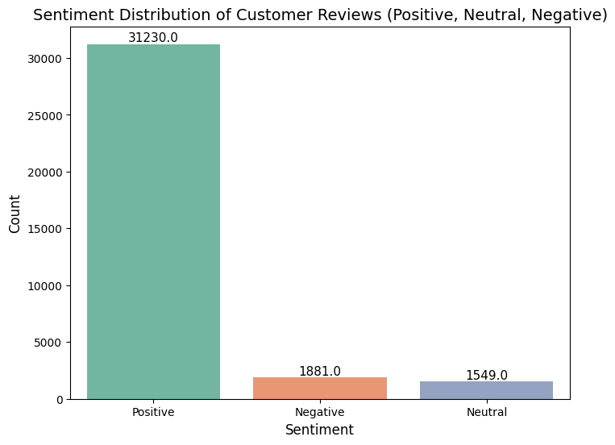

```python
plt.figure(figsize=(8, 6))

# Count plot with hue and palette to future-proof it
sns.countplot(data=df, x='sentiment', hue='sentiment', palette='Set2', legend=False)

# Title and labels
plt.title('Sentiment Distribution of Customer Reviews (Positive, Neutral, Negative)', fontsize=14)
plt.xlabel('Sentiment', fontsize=12)
plt.ylabel('Count', fontsize=12)

# Add data labels on top of bars
for p in plt.gca().patches:
    plt.gca().annotate(f'{p.get_height()}',
                       (p.get_x() + p.get_width() / 2, p.get_height()),
                       ha='center', va='bottom', fontsize=11)

plt.show()
```

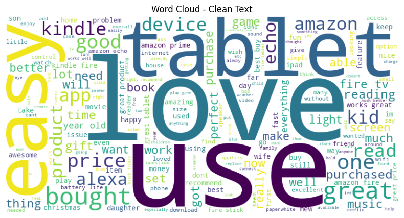

```python
from wordcloud import WordCloud

wordcloud = WordCloud(width=800, height=400,
                      background_color='white').generate(' '.join(df['Cleaned_Review'].dropna()))
plt.figure(figsize=(10, 5))
plt.imshow(wordcloud, interpolation='bilinear')
plt.axis('off')
plt.title("Word Cloud - Clean Text")
plt.show()
```

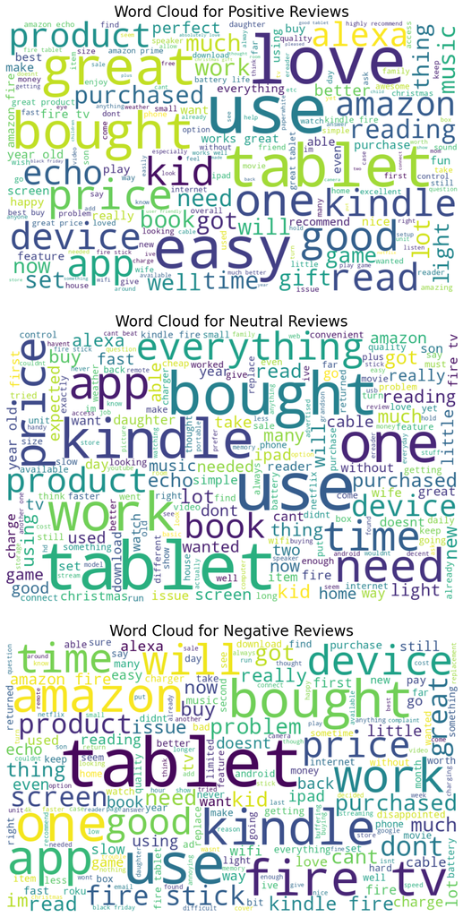

```python
sentiments = ['Positive', 'Neutral', 'Negative']
titles = {
    'Positive': 'Word Cloud for Positive Reviews',
    'Neutral': 'Word Cloud for Neutral Reviews',
    'Negative': 'Word Cloud for Negative Reviews'
}

wordclouds = {}
for sentiment in sentiments:
    reviews = " ".join(df.loc[df['sentiment'] == sentiment, 'Cleaned_Review'])
    wordcloud = WordCloud(
        width=1000,
        height=600,
        background_color='white',
        max_font_size=150
    ).generate(reviews)
    wordclouds[sentiment] = wordcloud

plt.figure(figsize=(10, 18))

for i, sentiment in enumerate(sentiments, 1):
    plt.subplot(3, 1, i)
    plt.imshow(wordclouds[sentiment], interpolation='bilinear')
    plt.title(titles[sentiment], fontsize=20)
    plt.axis('off')

plt.tight_layout(pad=3)
plt.show()
```

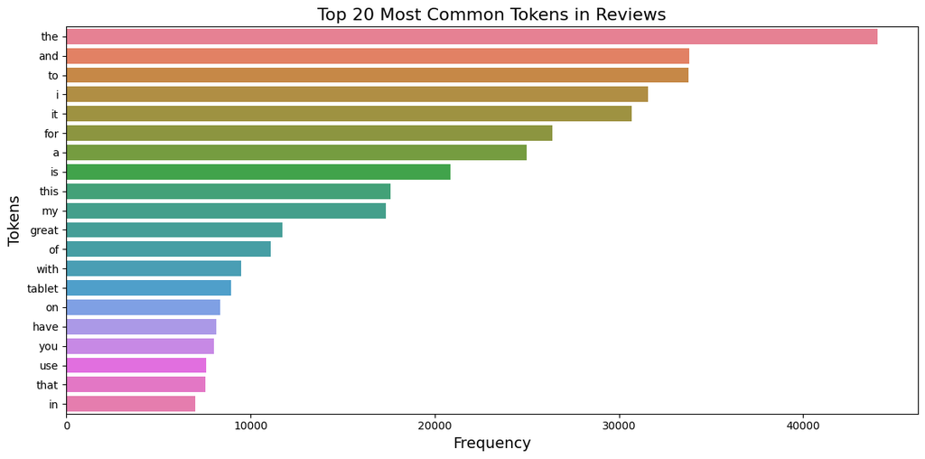

```python
# Combine all tokens
all_tokens = [token for tokens in df['Tokenized_Review'] for token in tokens]

# Count frequencies
token_counts = Counter(all_tokens)
common_tokens = token_counts.most_common(20)
tokens, frequencies = zip(*common_tokens)

# Plot
plt.figure(figsize=(12, 6))
sns.barplot(x=list(frequencies), y=list(tokens), hue=list(tokens), palette='husl', legend=False)

plt.title('Top 20 Most Common Tokens in Reviews', fontsize=16)
plt.xlabel('Frequency', fontsize=14)
plt.ylabel('Tokens', fontsize=14)
plt.grid(axis='x', linestyle='--', alpha=0.7)
plt.tight_layout()
plt.grid(False)
plt.show()
```

## 6. Machine learning

```python
print("Exact column names:")
for col in df.columns:
    print(f"- {col}")
```

```
Exact column names:
- id
- name
- asins
- brand
- categories
- keys
- manufacturer
- reviews.date
- reviews.dateAdded
- reviews.dateSeen
- reviews.didPurchase
- reviews.doRecommend
- reviews.id
- reviews.numHelpful
- reviews.rating
- reviews.sourceURLs
- reviews.text
- reviews.title
- reviews.userCity
- reviews.userProvince
- reviews.username
- Cleaned_Review
- Tokenized_Review
- No_Stopwords_Review
- Stemmed_Review
- vader_scores
- compound
- sentiment
```

### Column Pruning – Removing Irrelevant Features

To prepare the dataset for sentiment analysis, I removed a set of columns that were either irrelevant, redundant, or not useful for the modeling task. This step was essential to simplify the dataset, reduce memory usage, and eliminate noise that could interfere with downstream processing.

```python
# Deleting unwanted columns
df = df.drop(columns=[
    'id',
    'name',
    'asins',
    'brand',
    'categories',
    'keys',
    'manufacturer',
    'reviews.date',
    'reviews.dateAdded',
    'reviews.dateSeen',
    'reviews.didPurchase',
    'reviews.doRecommend',
    'reviews.id',
    'reviews.numHelpful',
    'reviews.rating',
    'reviews.sourceURLs',
    'reviews.title',
    'reviews.userCity',
    'reviews.userProvince',
    'reviews.username',
    'vader_scores',
])


# Displaying the first few rows of the dataframe to verify
df.head()
```

|  | reviews.text | Cleaned_Review | Tokenized_Review | No_Stopwords_Review | Stemmed_Review | compound | sentiment |
| --- | --- | --- | --- | --- | --- | --- | --- |
| 0 | This product so far has not disappointed. My c... | this product so far has not disappointed my ch... | [this, product, so, far, has, not, disappointe... | [product, far, disappointed, children, love, u... | [product, far, disappoint, children, love, use... | 0.9194 | Positive |
| 1 | great for beginner or experienced person. Boug... | great for beginner or experienced person bough... | [great, for, beginner, or, experienced, person... | [great, beginner, experienced, person, bought,... | [great, beginn, experienc, person, bought, gif... | 0.8934 | Positive |
| 2 | Inexpensive tablet for him to use and learn on... | inexpensive tablet for him to use and learn on... | [inexpensive, tablet, for, him, to, use, and, ... | [inexpensive, tablet, use, learn, step, nabi, ... | [inexpens, tablet, use, learn, step, nabi, thr... | 0.4404 | Positive |
| 3 | I've had my Fire HD 8 two weeks now and I love... | ive had my fire hd 8 two weeks now and i love ... | [ive, had, my, fire, hd, 8, two, weeks, now, a... | [ive, fire, hd, 8, two, weeks, love, tablet, g... | [ive, fire, hd, 8, two, week, love, tablet, gr... | 0.9875 | Positive |
| 4 | I bought this for my grand daughter when she c... | i bought this for my grand daughter when she c... | [i, bought, this, for, my, grand, daughter, wh... | [bought, grand, daughter, comes, visit, set, u... | [bought, grand, daughter, come, visit, set, us... | 0.7876 | Positive |

**Feature Extraction – TF-IDF Vectorization**

In order to train a machine learning model on textual data, it's necessary to first convert the text into a numerical representation. For this project, I used the TF-IDF (Term Frequency-Inverse Document Frequency) method to transform the cleaned reviews into a feature matrix.

```python
# Step 1: Convert text data into numerical features using TF-IDF
tfidf_vectorizer = TfidfVectorizer(max_features=5000)  # Limiting to top 5000 features

# Training and testing division
X = tfidf_vectorizer.fit_transform(df['Cleaned_Review'])
y = df['sentiment']

tfidf_vectorizer
```

```
TfidfVectorizer(max_features=5000)
```

Data Splitting Using Scikit-learn’s train_test_split, I divided the TF-IDF feature matrix and sentiment labels:

80% of the data was used for training (X_train, y_train).

20% was reserved for testing (X_test, y_test).

This procedure is crucial for accurately evaluating the model's performance. The training set allows the model to learn patterns and relationships within the data, while the test set, which the model has not seen during training, is used to validate its ability to generalize and predict new data.

```python
# Training and testing division
X_train, X_test, y_train, y_test = train_test_split(X, y, test_size=0.2, random_state=42)
```

Converting Sparse to Dense Format TF-IDF produces a sparse matrix, which is efficient in memory but not always compatible with every model or analysis method. For algorithms or tools that require dense inputs (like visualizations or some types of classifiers), I converted the sparse matrices into dense arrays.

```python
# Convert your TF-IDF sparse matrix to a dense matrix
X_train_dense = X_train.toarray()
X_test_dense = X_test.toarray()
```

```python
models = [
    # Random Forest
    RandomForestClassifier(n_estimators=100, random_state=42),

    # Logistic Regression
    LogisticRegression(random_state=50)
]

# Evaluate each model
for i, model in enumerate(models):
    model.fit(X_train, y_train)
    train_accuracy = accuracy_score(y_train, model.predict(X_train))
    test_accuracy = accuracy_score(y_test, model.predict(X_test))

    print(f"Model {i+1}: {type(model).__name__}")
    print(f"Training Accuracy: {train_accuracy:.4f}")
    print(f"Testing Accuracy: {test_accuracy:.4f}")
    print("-----------------")
```

```
Model 1: RandomForestClassifier
Training Accuracy: 1.0000
Testing Accuracy: 0.9067
-----------------
Model 2: LogisticRegression
Training Accuracy: 0.9322
Testing Accuracy: 0.9169
-----------------
```

**2. Model 2: LogisticRegression**

Training Accuracy: 93.22% Testing Accuracy: 91.69% Analysis: Logistic Regression shows a healthy balance between training and testing accuracies. Both are close, indicating that the model generalizes well without overfitting or underfitting. This makes it one of the most balanced models in this comparison.

## 7. Evaluation metrics Report

```
Model 1: RandomForestClassifier
Training Accuracy: 1.0000
Testing Accuracy: 0.9067
```

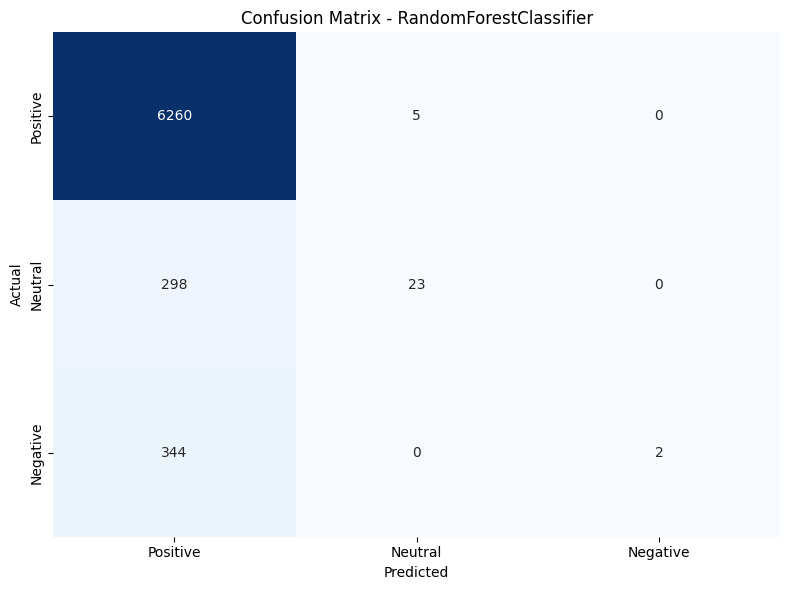

```
Model 2: LogisticRegression
Training Accuracy: 0.9322
Testing Accuracy: 0.9169
```

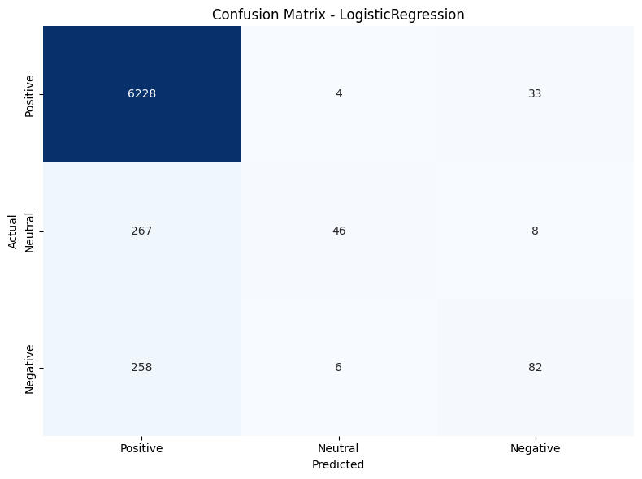

```python
# Define your sentiment labels
labels = ['Positive', 'Neutral', 'Negative']

# Evaluate each already-trained model
for i, model in enumerate(models):
    y_train_pred = model.predict(X_train)
    y_test_pred = model.predict(X_test)

    train_accuracy = accuracy_score(y_train, y_train_pred)
    test_accuracy = accuracy_score(y_test, y_test_pred)

    print(f"\nModel {i+1}: {type(model).__name__}")
    print(f"Training Accuracy: {train_accuracy:.4f}")
    print(f"Testing Accuracy: {test_accuracy:.4f}")

    # Confusion matrix
    cm = confusion_matrix(y_test, y_test_pred, labels=labels)

    # Plot confusion matrix
    plt.figure(figsize=(8, 6))
    sns.heatmap(cm, annot=True, fmt="d", cmap="Blues", cbar=False,
                xticklabels=labels, yticklabels=labels)
    plt.xlabel("Predicted")
    plt.ylabel("Actual")
    plt.title(f"Confusion Matrix - {type(model).__name__}")
    plt.tight_layout()
    plt.show()
```

**Model 1: RandomForestClassifier**

**Model 2: LogisticRegression**

## 8. Analysis classification reports for the 2 models

```python
# Define sentiment labels
sentiment_labels = ['Positive', 'Neutral', 'Negative']

# ---------------------------
# Random Forest
# ---------------------------
print("RandomForestClassifier")

rf_model = RandomForestClassifier(random_state=42)
rf_model.fit(X_train, y_train)

y_train_pred = rf_model.predict(X_train)
y_test_pred = rf_model.predict(X_test)

print(f"Training Accuracy: {accuracy_score(y_train, y_train_pred):.4f}")
print(f"Testing Accuracy: {accuracy_score(y_test, y_test_pred):.4f}")
print("\nClassification Report:")
print(classification_report(y_test, y_test_pred, target_names=sentiment_labels))
print("=======================================\n")

# ---------------------------
# Logistic Regression
# ---------------------------
print("LogisticRegression")

lr_model = LogisticRegression(max_iter=1000, random_state=42)
lr_model.fit(X_train, y_train)

y_train_pred = lr_model.predict(X_train)
y_test_pred = lr_model.predict(X_test)

print(f"Training Accuracy: {accuracy_score(y_train, y_train_pred):.4f}")
print(f"Testing Accuracy: {accuracy_score(y_test, y_test_pred):.4f}")
print("\nClassification Report:")
print(classification_report(y_test, y_test_pred, target_names=sentiment_labels))
print("=======================================\n")
```

[output not shown]

**1. RandomForestClassifier**

Training Accuracy: 100%

Testing Accuracy: 90.67%

**2. LogisticRegression**

**Training Accuracy: 93.22%**

**Testing Accuracy: 91.69%**

### Project Overview

This project created a natural language processing pipeline for the sentiment analysis of reviews from Amazon products. The goal is to segregate reviews into positive, neutral, and negative categories in order to leverage the information from the text.

The methods combined in this project included:

- Text cleaning
- Sentiment tagging using VADER
- TF-IDF vectorization
- Prepare the dataset for a machine learning task (train-test-split, convert to dense)

### Weaknesses

1. **Sentiment Distribution:** There is quite a high number of Positive reviews which is generally presumed, but it plays into the models. This impacts how well the model works, unless later balance techniques are applied.
2. **VADER Drawbacks:** While certainly VADER is fast, it does have drawbacks.
   - It can not determine meaning from context or sarcasm.
   - It does use a fixed set of words and can not learn.
   - It can miscalculate a subtle or pointed comment.
3. **Sparse Features and Memory:** TF-IDF makes sense, but creates larger, sparse matrices. Changing this to a dense matrix can create additional memory usage, particularly with larger datasets.

There is potential for this sentiment dissection in business:

- It indicates customer opinion by tracking satisfaction over time or through products.
- It connects negative feedback, this is not lost hypothetically the organization could follow in an sequence.
- It has the potential to automate illegal content identification.
- It has the potential to support marketing and product teams by finding established, positive feedback received as promotion for features.

### Recommendations for Next Steps

1. **Balance the Data:** Improve results for the lesser common sentiment types by using oversampling, undersampling, or class weights.
2. **Combined Approach:** Combine VADER and supervised models to help improve performance and accuracy.
3. **Topic Grouping:** Generate review topics using LDA or similar techniques to gain insights beyond sentiment.
4. **Real-World Use:** Put the model into an API using Flask or FastAPI for real-time sentiment scoring.

### In Conclusion

This project shows how NLP can change text into useful insights. The pipeline works as a good starting point and can be improved. With more work, it can be used to make business choices and improve customer experience.